# 7. Introducción a las fertilizadoras

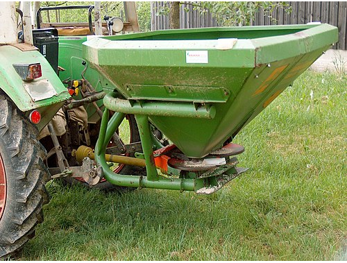

Fuente: Wikipedia. Fertilizadora adosada a un tractor con doble disco.

## Introducción

Este [video](https://www.youtube.com/watch?v=pfSDi5a7zQE) muestra algunas cosas interesantes sobre fertilización y es un buen disparador introductorio.

Se trata de una fertilizadora para fertilizantes sólidos que funciona a voleo y que permite regular bien la dosis. Además es apta para alta producción.

## Características de las fertilizadoras

Los fertilizantes se pueden aplicar antes de la siembra del cultivo o durante la siembra. Cuando se hace fuera del momento de la siembra se utilizan las fertilizadoras. Cuando se hace en el momento de la siembra las mismas sembradoras lo pueden hacer.

Cualquier fertilizadora debe tener cuatro características fundamentales:

- **1-** Uniformidad en la aplicación de la dosis
- **2-** Resistencia a la corrosión
- **3-** Diseño sencillo, fácil de desmotar y limpiar
- **4-** Capacidad para variar la dosis

## Actividad 1: características

Puedes ver este fragmento de [video](https://www.youtubetrimmer.com/view/?v=9cC852nPZ7E&start=0&end=87&loop=0) para repasar y pensar en lo visto en la introducción.

Responde con tus propias palabras. Es importante hacerlo así para que el trabajo no sea rechazado.

- **1-** Explica que es la uniformidad en la aplicación de la dosis (2 o 3 renglones).
- **2-** Si no pones mucha atención te puede parecer que “uniformidad en la aplicación de la dosis” y “capacidad de variar la dosis” son cosas que no se pueden dar al mismo tiempo en una máquina. Explica por que sí.
- **3-** ¿Por qué las fertilizadoras requieren buena resistencia a la corrosión y como se logra normalmente?

## Actividad 2: fertilizantes

En este [fragmento](https://www.youtubetrimmer.com/view/?v=9cC852nPZ7E&start=87&end=200&loop=0) puedes repasar sobre fertilizantes.

Copia el siguiente texto pero completado con las palabras que faltan. En cada línea `______` va una sola palabra. Si en la línea aparece una letra, como por ejemplo en `___f___` significa que tiene que ir una palabra que empieza con “f”.

*Los fertilizantes pueden ser sólidos o `______`. Los `______` pueden ser granulados o perlados. Ejemplo de fertilizantes sólidos son la urea, fosfato diamónico, yeso, etc. Pueden venir en bolsas de 50kg, en bolsones de 1000 kg o a `___g___`. En este último caso un camión lo descarga en una tolva y de la tolva pasa a la `___f___`. Los fertilizantes líquidos se aplican con `___p___`.*

## Actividad 3: Tipos de fertilizadoras para sólidos

Estas se pueden dividir en dos grandes grupos: a) de cobertura total o al voleo, y b) de aplicación localizada. Investiga y explica en 4 renglones como máximo, usando tus propias palabras, para qué se usa cada una.